# Lista de Exercícios IPE #2

Taiguara Melo Tupinambás

Entrega: 11 de abril de 2017

As 43a seções, equações, figuras, exemplos e exercícios são do livro *Intuitive Probability and Random Processes using MATLAB* de Stephen M. Kay, Springer, 2006.

## Exercício 1:

*i. Espaço de Probabilidade*

O espaço de probabilidade é dado pela tripla (${\Omega}$,F,P), formada por um conjunto ${\Omega}$ , uma conjunto de eventos F em ${\Omega}$ e uma medida positiva P para os eventos:

**${\Omega}$** = {todas as palavras formadas por 3 letras de um alfabeto com **n** letras}

**F** = {A,B,C}

**P** = {P(A),P(B),P(C)}

$$\begin{gather}
\small P(A) = \frac{1\times{n}\times{n}}{n^3} = \frac{1}{n} \\
\small P(B) = \frac{n\times{1}\times{n}}{n^3} = \frac{1}{n} \\
\small P(C) = \frac{3\times{n}\times{(n-1)}}{n^3} = \frac{3n-3}{n^2}\\
\end{gather}$$

*ii. Independência dois a dois e três a três*

A${\cap}$B: palavra começa com **s** e tem a letra **s** no meio

$$\begin{gather}
\small P(A{\cap}B) = \frac{1\times{1}\times{n}}{n^3} = \frac{1}{n^2} = P(A)P(B)\\
\end{gather}$$

Logo, A e B são independentes

A${\cap}$C: palavra começa com **s** e tem duas letras exatamente iguais, i.e. as duas primeiras letras são **s**, a primeira e última são **s** e a do meio não ou as duas últimas são iguais e não são **s**

$$\begin{gather}
\small P(A{\cap}C) = \frac{[1\times{1}\times{(n-1)}]+[1\times{(n-1)}\times{1}]+[1\times{(n-1)}\times{1}]}{n^3} = \frac{3n-3}{n^3} = P(A)P(C)
\end{gather}$$

Logo, A e C são independentes

B${\cap}$C: palavra tem **s** no meio e tem duas letras exatamente iguais, i.e. as duas primeiras letras são **s**, a segunda e última são **s** e a primeira não ou a primeira e última são iguais e não são **s**

$$\begin{gather}
\small P(A{\cap}C) = \frac{[1\times{1}\times{(n-1)}]+[(n-1)\times{(1)}\times{1}]+[1\times{(n-1)}\times{1}]}{n^3} = \frac{3n-3}{n^3} = P(B)P(C)
\end{gather}$$

Logo, A e C são independentes e **os eventos A, B e C são independentes dois a dois**.

A${\cap}$B${\cap}$C: palavra que começa com **s**, tem **s** no meio e tem duas letras exatamente iguais, i.e. as duas primeiras letras são **s** e a última, não.

$$\begin{gather}
\small P(A{\cap}B{\cap}C) = \frac{1\times{1}\times{(n-1)}}{n^3} = \frac{n-1}{n^3} \neq P(A)P(B)P(C) = \frac{3n-3}{n^4}
\end{gather}$$

Logo, **os eventos A, B e C não são independentes três a três**

*iii) Simulação para o caso n=6*

```r
#letras de 1 a 6 (s=1)
n=6
N=100000
A=0;B=0;C=0;

for (i in 1:N) {
        p=c(0,0,0)
        for (j in 1:3) {
        p[j]=floor(runif(1,1,7))
        }
        if (p[1]==1){
                A=A+1
        }
        if (p[2]==1){
                B=B+1
        }
        if (p[1]==p[2]&p[1]!=p[3] | p[1]==p[3]&p[1]!=p[2] | p[2]==p[3]&p[2]!=p[1]) {
                C=C+1
        }
}

cat("P(A) simulado =",A/N,"\nP(B) simulado =", B/N,"\nP(C) simulado =",C/N)
```

```
## P(A) simulado = 0.16578
## P(B) simulado = 0.1665
## P(C) simulado = 0.41529
```

```r
cat("P(A) teórico =",1/n,"\nP(B) teórico =", 1/n,"\nP(C) teórico =",(3*n-3)/n^2)
```

```
## P(A) teórico = 0.1666667
## P(B) teórico = 0.1666667
## P(C) teórico = 0.4166667
```

## Exercício 2:

1. Evento A:

$$\begin{equation}
\small y \geq x
\end{equation}$$

P(A) será a área à direita da reta y=x até encostar no retângulo, dividido pela área total do retângulo (ab).

Desta forma, para a>b
$$\begin{gather}
\small P(A) = \frac{1}{ab}\times\int_0^b xdx. = \frac{1}{ab}\times\frac{b^2}{2} = \frac{b}{2a}
\end{gather}$$
para b>a
$$\begin{gather}
\small P(A) = \frac{1}{ab}\times\int_0^a xdx. = \frac{1}{ab}\times\frac{a^2}{2} = \frac {a}{2b}
\end{gather}$$

2. Evento B:

$$\begin{gather}
\small bx+ay \leq \frac{ab}{2} \\
\small y \leq \frac{b}{2}-\frac{bx}{a}
\end{gather}$$

Desta forma, P(B) é a área debaixo da reta definida pela desigualdade acima dentro do retângulo, dividido pela área do retângulo (ab) Fazendo a integral da função em x variando de 0 a a/2, temos que:

$$\begin{gather*}
\small P(B) = \frac{1}{ab}\times\int_0^\frac{a}{2} (\frac{b}{2}-\frac{bx}{a})dx. = \frac{1}{ab}\times\frac{ba}{8}=\frac{1}{8}=0.125
\end{gather*}$$

3. Evento C:

$$\begin{gather}
\small bx+ay \geq \frac{ab}{3} \\
\small y \geq \frac{b}{3}-\frac{bx}{a}
\end{gather}$$

Desta forma, P(C) é a área acima da reta definida pela desigualdade limitada pelo retângulo, dividido pela área do retângulo (ab) Fazendo a integral da função em x variando de 0 a a/3, temos que:

$$\begin{gather}
\small P(C) =1- \frac{1}{ab}\times\int_0^\frac{a}{3} (\frac{b}{3}-\frac{bx}{a})dx. =1- \frac{1}{ab}\times\frac{ba}{18}=\frac{17}{18}=0.9444 \\
\end{gather}$$

4. Evento d:

$$\begin{gather}
\small x+y < \frac{1}{3} \\
\small y < \frac{1}{3}-x
\end{gather}$$

- Verificando se B e C são independentes

A probabilidade da interseção entre B e C é a área entre as retas definidas pela desigualdade de B e C. Logo temos que:

$$\begin{gather}
\small P(B{\cap}C) = \frac{1}{ab}\times[\int_0^\frac{a}{2} (\frac{b}{2}-\frac{bx}{a})dx-\int_0^\frac{a}{3} (\frac{b}{3}-\frac{bx}{a})dx]. = \frac{5}{72}=0.06944 \\
\small P(B)\times P(C)=\frac{17}{144}=0.118\neq P(B{\cap}C)
\end{gather}$$

Logo, **B e C não são independentes**

*- Os resultados para a simulação (a=b=1) são apresentados abaixo (todos conforme os valores teóricos calculados)*

```r
N=100000
a=1
b=1
x=runif(N,0,a)
y=runif(N,0,b)
A=0;B=0;C=0;D=0;BC=0;

for (i in 1:N) {
        if (x[i]<y[i]) {
                A=A+1
        }
        if (b*x[i]+a*y[i]<=a*b/2) {
                B=B+1
        }
        if (b*x[i]+a*y[i]>=a*b/3) {
                C=C+1
        }
        if (x[i]+y[i]<1/3) {
                D=D+1
        }
        if (b*x[i]+a*y[i]<=a*b/2 & b*x[i]+a*y[i]>=a*b/3) {
                BC=BC+1
        }
}

cat("P(A)=",A/N,"\nP(B) =", B/N,"\nP(C) =",C/N,"\nP(D) =",D/N,
    "\nP(BC) =",BC/N,"\nP(B)P(C) =",(B/N)*(C/N))
```

```
## P(A)= 0.50025
## P(B) = 0.124
## P(C) = 0.94459
## P(D) = 0.05541
## P(BC) = 0.06859
## P(B)P(C) = 0.1171292
```

## Exercício 3:

Para que a raíz seja imaginária, é necessário que:

$$\begin{gather}
\small \sqrt{b^2-4ac}<0
\end{gather}$$

```r
N=100000
a=runif(N,1,2)
b=runif(N,5,6)
c=runif(N,2,5)

for (i in 1:N) {
        x[i]=b[i]^2-4*a[i]*c[i]
}

cat("P(raízes imaginárias) =",sum(x<0)/N)
```

```
## P(raízes imaginárias) = 0.11839
```

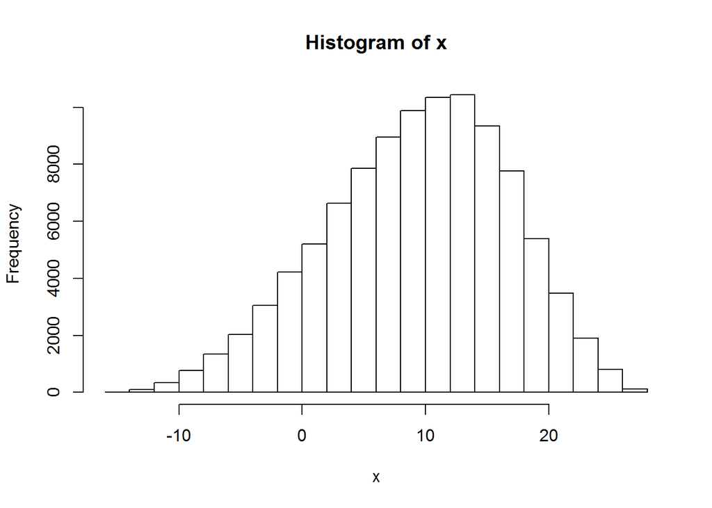

```r
hist(x)
```

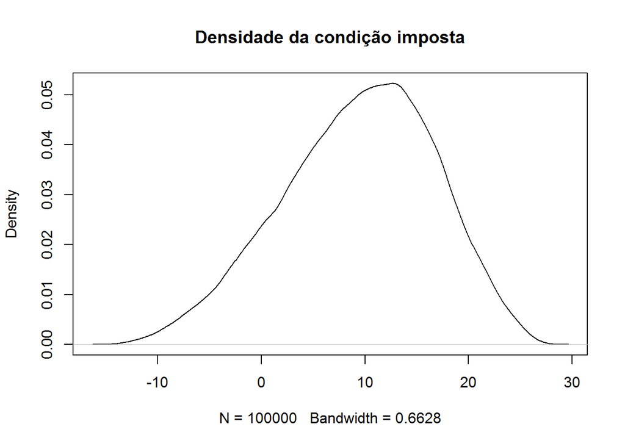

```r
plot(density(x),main="Densidade da condição imposta")
```

O histograma da condição imposta parece tender à uma distribuição do tipo gama (negativa), conforme Figura 1 abaixo:

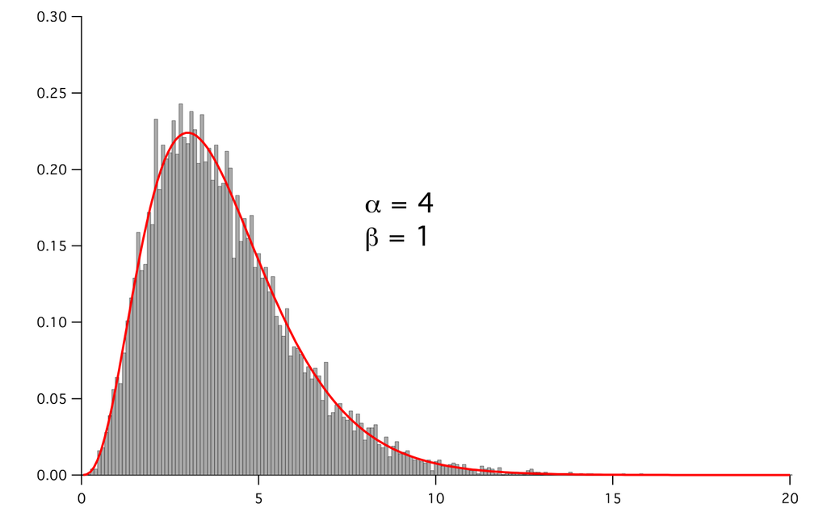

Exemplo de Distribuição gama

## Exercício 4:

A probabilidade da carta estar no arquivo 1 (Evento B), dado que ela não foi encontrada no arquivo 1 (Evento A), é dada por:

$$\begin{gather}
\small P[B|A]=\frac{P[A|B]\times P[B]}{P[A]}
\end{gather}$$

Sabemos que:

É necessário cacular a probabilidade de encontrar a carta P[A], para resolver o problema.

Com esta informação, podemos resolver o problema:

$$\begin{gather*}
\small P[B|A]=\frac{P[A|B]\times P[B]}{P[A]}\\
\small P[B|A]=\frac{(1-\alpha_1)*\frac{1}{3}}{\frac{(3-\alpha_1)}{3}}=\frac{1-\alpha_1}{3-\alpha_1}
\end{gather*}$$

## Exercício 5:

# Exercício 3.34 do livro

A probabilidade de se obter uma bola vermelha e uma bola preta em qualquer ordem é:

$$\begin{gather}
\small P[{R,B}]+P[{B,R}]=\frac{4}{6}\times\frac{2}{5}+\frac{2}{6}\times\frac{4}{5}=\frac{8}{15}=0.53333
\end{gather}$$

```r
eventos=0;k=1;total_r=4;total_b=2
for (i in 1:total_r) {
        for (j in 1:total_b) {
                remove(x)
                x=paste("R",i)
                x=paste(x,"B",j)
                eventos[k]=x
                k=k+1
        }
}
for (i in 1:total_b) {
        for (j in 1:total_r) {
                remove(x)
                x=paste("B",i)
                x=paste(x,"R",j)
                eventos[k]=x
                k=k+1
        }
}
Tab_eventos<-data.frame(table(eventos))
print(Tab_eventos[1])
```

```
##    eventos
## 1  B 1 R 1
## 2  B 1 R 2
## 3  B 1 R 3
## 4  B 1 R 4
## 5  B 2 R 1
## 6  B 2 R 2
## 7  B 2 R 3
## 8  B 2 R 4
## 9  R 1 B 1
## 10 R 1 B 2
## 11 R 2 B 1
## 12 R 2 B 2
## 13 R 3 B 1
## 14 R 3 B 2
## 15 R 4 B 1
## 16 R 4 B 2
```

```r
total=(total_r+total_b)*(total_r+total_b-1)
Prob_eventos=length(eventos)/total
cat("Probabilidade simulada é igual a ",Prob_eventos)
```

```
## Probabilidade simulada é igual a  0.5333333
```

# Exercício 3.37 do livro

```r
Stir=0
Fact=0
for (i in 1:100) {
        Stir[i]=sqrt(2*pi)*i^(i+1/2)*exp(-i)
        Fact[i]=factorial(i)
}
result=data.frame(Stir,Fact,log(Stir),log(Fact),Fact/Stir)
print(result)
```

```
##              Stir          Fact    log.Stir.   log.Fact. Fact.Stir
## 1    9.221370e-01  1.000000e+00  -0.08106147   0.0000000  1.084438
## 2    1.919004e+00  2.000000e+00   0.65180648   0.6931472  1.042207
## 3    5.836210e+00  6.000000e+00   1.76408154   1.7917595  1.028065
## 4    2.350618e+01  2.400000e+01   3.15726316   3.1780538  1.021008
## 5    1.180192e+02  1.200000e+02   4.77084705   4.7874917  1.016784
## 6    7.100782e+02  7.200000e+02   6.56537508   6.5792512  1.013973
## 7    4.980396e+03  5.040000e+03   8.51326465   8.5251614  1.011968
## 8    3.990240e+04  4.032000e+04  10.59419164  10.6046029  1.010466
## 9    3.595369e+05  3.628800e+05  12.79257202  12.8018275  1.009298
## 10   3.598696e+06  3.628800e+06  15.09608201  15.1044126  1.008365
## 11   3.961563e+07  3.991680e+07  17.49473417  17.5023078  1.007602
## 12   4.756875e+08  4.790016e+08  19.98027166  19.9872145  1.006967
## 13   6.187239e+09  6.227021e+09  22.54575486  22.5521639  1.006430
## 14   8.666100e+10  8.717829e+10  25.18526981  25.1912212  1.005969
```

[output cut: 86 more lines]

```r
Stir200=sqrt(2*pi)*200^(200+1/2)*exp(-200)
print(Stir200)
```

```
## [1] Inf
```

```r
Fat200=factorial(200)
print(Fat200)
```

```
## [1] Inf
```

Observa-se que a aproximação tende a reduzir o erro percentual (a ultima coluna é a divisão do valor real (factorial) pela aproximação) quando maior for o número.

Sobre o cálculo para fatorial de 200, em ambos os casos ultrapassa os limites computacionais, produzindo o resultado Inf.